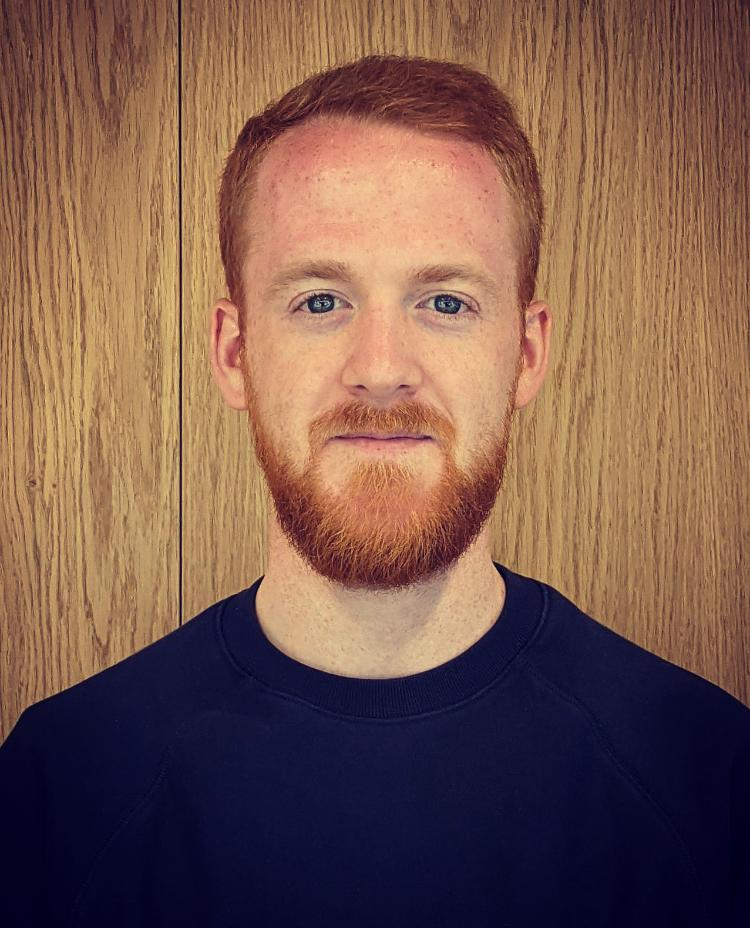

# Maximilian Amberg

## Bio

My name is Maximilian Amberg and I am a PhD candidate in the working group [Economic Growth and Human Development](https://www.mcc-berlin.net/forschung/arbeitsgruppen/wirtschaftswachstum-und-menschliche-entwicklung.html) at [MCC Berlin](https://www.mcc-berlin.net/en/index.html). By focusing on rigorous evaluations of current climate change mitigation policies, I seek to contribute to the recent policy debates regarding their efficiency as well as welfare and equity impacts. To that end, I combine methodologies for causal impact and welfare analysis with the power of novel datasets to improve public policy making on pressing environmental policy challenges. For details on my education, work experience, etc., see below.

## Work Address

**Mercator Research Institute on Global Commons and Climate Change (MCC)**

Torgauer Str. 12-15

10829 Berlin

Phone: +49 17657875740

E-Mail: amberg@mcc-berlin.net

## Education

**University of Potsdam** and **MCC Berlin** | Potsdam/Berlin, Germany

PhD Candidate | Supervisor: Prof. Dr. Matthias Kalkuhl; co-supervisor: Dr. Nicolas Koch | *forthcoming: August 2022 -*

**University of Mannheim** | Mannheim, Germany

M.Sc. in Economics | August 2019 - February 2022

**Technical University Berlin** | Berlin, Germany

Guest Student | April 2019 - July 2019

**Sciences Po** | Paris, France

Erasmus Semester | August 2017 - December 2017

**Heidelberg University** | Heidelberg, Germany

B.Sc. in Economics | September 2015 - July 2019

**Berufliche Schulen Gelnhausen (Wirtschaftsgymnasium)** | Gelnhausen, Germany

A-level | July 2012 - July 2015

## Experience

**MCC Berlin** | Working group: Economic Growth and Human Development | Graduate Research Assistant | March 2022 - Present | Berlin, Germany

**MCC Berlin** | Working group: Economic Growth and Human Development | Student Assistant | August 2019 - February 2022 | Berlin, Germany

**MCC Berlin** | Working group: Economic Growth and Human Development | Research Internship | April 2019 - July 2019 | Berlin, Germany

**Heidelberg University** | Chair of Environmental Economics (Jun.-Prof. Dr. Florian Diekert); NATCOOP (ERC) Project | Student Assistant | August 2018 - March 2019

**Helmholtz Zentrum für Umweltforschung (UFZ)** | Department of Economics | Working group: Energy (Prof. Dr. Erik Gawel) | Research Internship | January 2018 - April 2018 | Leipzig, Germany

### Fellowships and Grants

**Exposé Scholarship (German Academic Scholarship Foundation )** | March 2022 - Present

**German Academic Scholarship Foundation** | Mai 2019 - December 2021

**Erasmus Scholarship** | August 2017 - January 2018

**Cusanuswerk** | September 2015 - January 2022

### Computational Skills

**Programming** | R, Stata (advanced) | Python, MATLAB (intermediate) | GAMS, Java (basics)

**Geographic information** | QGIS/ArcGIS (intermediate)

**Version control** | GitHub/GitLab (daily business)

**Text processing** | LaTex/Overleaf, Word, Excel, PowerPoint (daily business)

### Publications

Kellner, M., Amberg, M., Bergmann, T., Roolfs, C., Kalkuhl, M. (2022). [Entlastungspakete für Energiepreisanstiege: Auswirkungen und Nachbesserungsbedarf.](https://doi.org/10.5281/zenodo.6617130) Zenodo.

Kalkuhl, M., Flachsland, C., Knopf, B., Amberg, M., Bergmann, T., Kellner, M., Stüber, S., Haywood, L., Roolfs, C., Edenhofer, O. (2022). [Auswirkungen der Energiepreiskrise auf Haushalte in Deutschland Sozialpolitische Herausforderungen und Handlungsoptionen.](https://www.mcc-berlin.net/fileadmin/data/C18_MCC_Publications/2022_MCC_Auswirkungen_der_Energiepreiskrise_auf_Haushalte.pdf) MCC Arbeitspapier.

Kopernikus-Projekt Ariadne (2021). [Reformoptionen für ein nachhaltiges Steuer- und Abgabensystem. Wie Lenkungssteuern effektiv und gerecht für den Klima- und Umweltschutz ausgestaltet werden können.](https://ariadneprojekt.de/media/2021/05/Ariadne-Kurzdossier_Steuerreform_Juni2021.pdf) Ariadne Kurzdossier.

Roolfs, C., Kalkuhl, M., Amberg, M., Bergmann, T., Kellner, M. (2021). [Documentation of the CO₂-price incidence webtool ‘MCC CO₂-Preis-Rechner’ (Version 1.0)](http://doi.org/10.5281/zenodo.5094561). Zenodo.

Kalkuhl, M., Amberg, M., Roolfs, C., Bergmann, T., Kellner, M. (2021). [MCC CO₂-Preis-Rechner (Version 1.0)](http://www.mcc-berlin.net/co2preisrechner).

Gawel, E., Amberg, M. (2018): [Ausschreibungen im EEG – eine Auswertung der bisherigen Erfahrungen](https://www.ufz.de/index.php?de=20939&pub_id=20779). Energiewirtschaftliche Tagesfragen 68 (7/8), 24-30.

### Assistance

#### Papers, Reports, and Dossiers

Kalkuhl, M., Knopf, B., Edenhofer, O. (2021). [CO₂-Bepreisung: Mehr Klimaschutz mit mehr Gerechtigkeit.](https://www.mcc-berlin.net/fileadmin/data/C18_MCC_Publications/2021_MCC_Klimaschutz_mit_mehr_Gerechtigkeit.pdf) MCC Arbeitspapier.

Edenhofer, O., Flachsland, C., Kalkuhl, M., Knopf, B., Pahle, M. (2019). [Optionen für eine CO₂-Preisreform. MCC-PIK-Expertise für den Sachverständigenrat zur Begutachtung der gesamtwirtschaftlichen Entwicklung.](https://www.mcc-berlin.net/fileadmin/data/B2.3_Publications/Working%20Paper/2019_MCC_Optionen_f%C3%BCr_eine_CO2-Preisreform_final.pdf) Working Paper Nr. 04/2019.

#### Newspaper Articles

[Warum der CO₂-Preis an die Bürger fließen muss](https://www.spiegel.de/wirtschaft/klimaforscher-raten-zu-hoeheren-co2-preisen-und-einem-sozialen-ausgleich-fuer-die-buerger-a-1d7deba3-c66a-4324-9f74-d6e198240f0b) | Spiegel | June 2021

[Forscher beziffern Umweltschäden auf 670 Milliarden Euro](https://www.spiegel.de/wirtschaft/service/nachhaltigkeit-forscher-beziffern-umweltschaeden-in-deutschland-auf-670-milliarden-euro-a-4521d7ef-8375-4b2d-a6f5-80057fed55c8) | Spiegel | June 2021

Luftverschmutzung, Überdüngung, Plastikmüll: Erstmals zeigt eine Studie, wie viele Milliarden Deutschland durch Umweltzerstörung verliert | Handelsblatt | June 2021

[Wie teuer die CO₂-Steuer für die Bürger wirklich wird](https://www.wiwo.de/my/politik/deutschland/exklusive-berechnungen-wie-teuer-die-co2-steuer-fuer-die-buerger-wirklich-wird/24274708.html) | WirtschaftsWoche | May 2019